# ST1131 Introduction to Statistics and Statistical Computing

## Tutorial 9

```python
# Verify the notebook is using venv-st1131
# You should see either \venv-st1131\Scripts\python.exe or /venv-st1131/bin/python
import sys
from pathlib import Path
print(Path(*Path(sys.executable).parts[-3:]))
```

```
venv-st1131v2\Scripts\python.exe
```

```python
# Verify required packages
import numpy as np
import pandas as pd
import matplotlib.pyplot as plt
from scipy import stats

print("Everything works!")
```

```
Everything works!
```

Some important functions we will use are:

- `stats.levene(x, y)` performs the equal variance test, with $H_0$: the two populations have the same variance, against $H_1$: they have different variances.
- `stats.ttest_ind(x, y, equal_var, alternative)` performs a two-sample $t$-test for independent samples, testing $\mu_X - \mu_Y$. Use `equal_var=True` if the equal variance test has a large $p$-value, and `equal_var=False` otherwise.
- `stats.ttest_rel(x, y, alternative)` performs a paired (dependent samples) $t$-test. It is the same as a one-sample $t$-test on the differences `x - y`.
- `result.confidence_interval(0.95)` gives the confidence interval from the result of a $t$-test, with its two ends stored in `.low` and `.high`. For `ttest_ind`, it is a confidence interval for $\mu_X - \mu_Y$.
- `stats.probplot(data, plot=plt)` draws a QQ plot to check whether the data are approximately normal.
- `stats.shapiro(data)` performs the Shapiro-Wilk test, with $H_0$: the sample is from a normal distribution, against $H_1$: it is not.

The `alternative` argument is `"two-sided"` (the default), `"greater"` or `"less"`, and it always refers to the first sample minus the second.

### Question 1

The $p$-value for testing $H_0: \mu = 100$ vs $H_1: \mu \ne 100$ is $0.043$, where $\mu$ is the mean of a population.

(a) What decision is made at significance level 0.05?

Since the $p$-value of 0.043 is less than 0.05, we reject $H_0$. At significance level $\alpha=0.05$, we conclude that the population mean $\mu$ is not equal to 100.

(b) If the decision in part (a) is wrong, what type of error has been made?

In part (a), we rejected $H_0$. If this decision is wrong, then $H_0$ is actually true, so this is a **Type I error** (rejecting $H_0$ when it is true).

This would happen if the true mean is in fact 100, but by chance we obtained a sample that gave a small $p$-value of 0.043, which led us to reject $H_0: \mu = 100$.

(c) Does a 95% confidence interval for $\mu$ contain 100? Explain.

No. A two-sided test at significance level $\alpha$ rejects $H_0: \mu = \mu_0$ exactly when $\mu_0$ lies outside the $100(1-\alpha)\%$ confidence interval for $\mu$.

Since the two-sided test rejects $H_0: \mu = 100$ at significance level 0.05, the 95% confidence interval for $\mu$ does not contain 100.

### Question 2

A survey asked respondents how many hours a week they spend on the internet. The data were randomly collected and are recorded in the file `internet_hours.csv`. Use Python to answer the questions below.

(a) Identify the response variable and the explanatory variable. Indicate whether each variable is quantitative or categorical.

- The **response variable** is the number of hours a week spent on the internet (`hours`). It is **quantitative**.
- The **explanatory variable** is the respondent's gender (`gender`). It is **categorical**.

(b) Perform a test of whether the population variances of the number of hours spent on the internet are equal for the two genders at significance level 0.05.

```python
internet = pd.read_csv("../data/internet_hours.csv")

female = internet.loc[internet['gender'] == 'female', 'hours']
male = internet.loc[internet['gender'] == 'male', 'hours']

print(f"Female: n = {len(female)}, mean = {female.mean():.4f}, sd = {female.std():.4f}")
print(f"Male:   n = {len(male)}, mean = {male.mean():.4f}, sd = {male.std():.4f}")
```

```
Female: n = 778, mean = 11.2416, sd = 13.6620
Male:   n = 621, mean = 12.0902, sd = 16.5691
```

```python
result_lev = stats.levene(female, male)
print(f"Equal variance test p-value: {result_lev.pvalue:.4f}")
```

```
Equal variance test p-value: 0.1099
```

We use the equal variance test, with hypotheses

$H_0$: the two samples are from populations (females and males) with the same variance, vs

$H_1$: the two samples are from populations with different variances.

The $p$-value is 0.1099, which is greater than 0.05. We do not reject $H_0$, and conclude that the population variances of the hours spent on the internet can be assumed equal for females and males.

(c) Perform a test of whether the population mean number of hours spent on the internet is the same for the two genders. Make a decision at significance level 0.01.

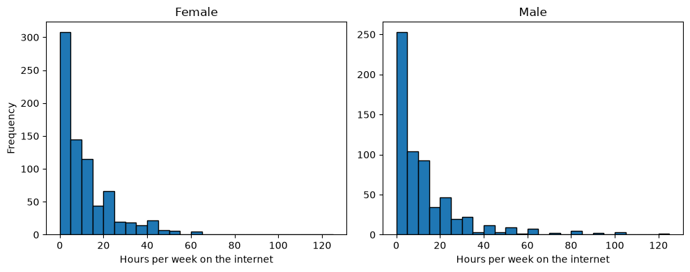

```python
fig, axes = plt.subplots(1, 2, figsize=(10, 4), sharex=True)

max_val = internet["hours"].max()
bins = np.arange(0, max_val + 5, 5)

axes[0].hist(female, bins=bins, edgecolor='black')
axes[0].set_title("Female")
axes[0].set_xlabel("Hours per week on the internet")
axes[0].set_ylabel("Frequency")

axes[1].hist(male, bins=bins, edgecolor='black')
axes[1].set_title("Male")
axes[1].set_xlabel("Hours per week on the internet")

plt.tight_layout()
plt.show()
```

```python
results = stats.ttest_ind(female, male, equal_var=True, alternative='two-sided')
print(f"t = {results.statistic:.4f}, df = {results.df:.0f}, p-value = {results.pvalue:.4f}")
```

```
t = -1.0497, df = 1397, p-value = 0.2940
```

**Assumptions**:

- The data were obtained by randomisation.
- The variable (hours spent on the internet per week) is quantitative, and it is the same variable for both groups.
- The two samples (females and males) are independent.
- The histograms of both groups are very right-skewed, so neither population is normal. However, the sample sizes (778 females and 621 males) are very large, so the $t$-test can still be used.
- From part (b), the two populations can be assumed to have equal variances, so we use `equal_var=True`.

**Hypotheses**: $$ H_0: \mu_X - \mu_Y = 0 \quad \text{vs} \quad H_1: \mu_X - \mu_Y \ne 0 $$ where $\mu_X$ and $\mu_Y$ are the population mean numbers of hours spent on the internet per week for females and males respectively.

**Test statistic**: $T = -1.050$, whose null distribution is $t_{1397}$ (since $df = 778 + 621 - 2 = 1397$).

**$p$-value and conclusion**: The $p$-value is 0.2940, which is greater than 0.01. We do not reject $H_0$. At significance level 0.01, there is no evidence that the mean number of hours spent on the internet per week differs between females and males.

(d) Report and interpret the 99% confidence interval for the difference between the population means for females and males.

```python
ci = results.confidence_interval(confidence_level=0.99)
print(f"99% CI for mu_X - mu_Y: ({ci.low:.4f}, {ci.high:.4f})")
```

```
99% CI for mu_X - mu_Y: (-2.9335, 1.2365)
```

The 99% confidence interval for $\mu_X - \mu_Y$ is $(-2.93,\ 1.24)$.

We are 99% confident that the population mean number of hours spent on the internet per week is between 2.93 hours lower and 1.24 hours higher for females than for males.

Since the interval contains 0, there is no evidence that the population mean time on the internet differs by gender. This is consistent with the decision in part (c).

(e) Repeat parts (c) and (d) with the significance level of part (b) changed to 0.15.

```python
# Equal variance test from part (b), now at significance level 0.15
print(f"Equal variance test p-value: {result_lev.pvalue:.4f}")

# Repeat part (c) with unequal variances
results_unequal = stats.ttest_ind(female, male, equal_var=False, alternative='two-sided')
print(f"t = {results_unequal.statistic:.4f}, df = {results_unequal.df:.2f}, p-value = {results_unequal.pvalue:.4f}")

# Repeat part (d)
ci_unequal = results_unequal.confidence_interval(confidence_level=0.99)
print(f"99% CI for mu_X - mu_Y: ({ci_unequal.low:.4f}, {ci_unequal.high:.4f})")
```

```
Equal variance test p-value: 0.1099
t = -1.0275, df = 1194.75, p-value = 0.3044
99% CI for mu_X - mu_Y: (-2.9791, 1.2821)
```

**Equal variance test at significance level 0.15**: The $p$-value of the equal variance test is 0.1099, which is now less than 0.15. We reject $H_0$ and conclude that the population variances of the hours spent on the internet are different for females and males. We therefore use `equal_var=False`.

**Part (c) repeated**:

- **Assumptions**: The same as in part (c), except that the two populations now have unequal variances.
- **Hypotheses**: The same as in part (c), $$ H_0: \mu_X - \mu_Y = 0 \quad \text{vs} \quad H_1: \mu_X - \mu_Y \ne 0 $$ where $\mu_X$ and $\mu_Y$ are the population mean numbers of hours spent on the internet per week for females and males respectively.
- **Test statistic**: $T = -1.027$, whose null distribution is $t_{1194.75}$. With unequal variances, the $df$ is not a whole number, since it comes from a more complicated formula computed by software.
- **$p$-value and conclusion**: The $p$-value is 0.3044, which is greater than 0.01. We do not reject $H_0$. At significance level 0.01, there is no evidence that the mean number of hours spent on the internet per week differs between females and males.

**Part (d) repeated**: The 99% confidence interval for $\mu_X - \mu_Y$ is $(-2.98,\ 1.28)$. We are 99% confident that the population mean number of hours spent on the internet per week is between 2.98 hours lower and 1.28 hours higher for females than for males. Since the interval contains 0, there is no evidence that the population mean time on the internet differs by gender.

**Comparison**: Changing the significance level of the equal variance test changes its decision, so we switch from `equal_var=True` to `equal_var=False`. However, the results barely change:

|  | Equal variances | Unequal variances |
| --- | --- | --- |
| Test statistic | $-1.050$ | $-1.027$ |
| $df$ | 1397 | 1194.75 |
| $p$-value | 0.2940 | 0.3044 |
| 99% CI | $(-2.93,\ 1.24)$ | $(-2.98,\ 1.28)$ |

The conclusions in parts (c) and (d) stay the same. When both sample sizes are large, the choice between equal and unequal variances rarely changes the conclusion of the $t$-test.

### Question 3

The following measurements of corneal thickness were obtained from 8 randomly selected subjects, each affected by glaucoma in one eye. For each subject, the thickness was measured in both the eye affected by glaucoma and the unaffected eye.

| Glaucoma | Unaffected |
| --- | --- |
| 488 | 484 |
| 468 | 478 |
| 480 | 492 |
| 426 | 444 |
| 440 | 436 |
| 402 | 398 |
| 458 | 464 |
| 460 | 476 |

(a) Perform a paired (dependent samples) $t$-test to decide whether glaucoma decreases the thickness of the cornea, at significance level 0.05.

```
Differences (glaucoma - unaffected): [  4 -10 -12 -18   4   4  -6 -16]
Mean of differences = -6.2500, sd of differences = 9.2234
```

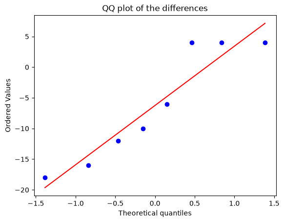

```
Shapiro-Wilk test p-value: 0.1276
```

```python
glaucoma = np.array([488, 468, 480, 426, 440, 402, 458, 460])
unaffected = np.array([484, 478, 492, 444, 436, 398, 464, 476])
diff = glaucoma - unaffected

print("Differences (glaucoma - unaffected):", diff)
print(f"Mean of differences = {diff.mean():.4f}, sd of differences = {diff.std(ddof=1):.4f}")

plt.figure()
stats.probplot(diff, plot=plt)
plt.title("QQ plot of the differences")
plt.show()

result_sw = stats.shapiro(diff)
print(f"Shapiro-Wilk test p-value: {result_sw.pvalue:.4f}")
```

```python
results = stats.ttest_rel(glaucoma, unaffected, alternative='less')
print(f"t = {results.statistic:.4f}, df = {results.df}, p-value = {results.pvalue:.4f}")

# Equivalently, a one-sample t-test on the differences
results_1samp = stats.ttest_1samp(diff, popmean=0, alternative='less')
print(f"t = {results_1samp.statistic:.4f}, df = {results_1samp.df}, p-value = {results_1samp.pvalue:.4f}")
```

```
t = -1.9166, df = 7, p-value = 0.0484
t = -1.9166, df = 7, p-value = 0.0484
```

Since both measurements come from the same person, the two samples are dependent (matched pairs). We therefore analyse the differences $D = \text{Glaucoma} - \text{Unaffected}$.

**Assumptions**:

- The data were obtained by randomisation.
- The variable (corneal thickness) is quantitative.
- With only 8 differences, the sample size is small, so the population of differences should be approximately normal. A histogram of 8 values tells us very little, so we use a QQ plot and the Shapiro-Wilk test. The points in the QQ plot lie reasonably close to the line, and the Shapiro-Wilk test has a $p$-value of 0.1276, which is greater than 0.05. We do not reject normality, so the normality assumption is reasonable.

**Hypotheses**: $$ H_0: \mu_D = 0 \quad \text{vs} \quad H_1: \mu_D < 0 $$ where $\mu_D$ is the population mean of the differences in corneal thickness (glaucoma eye minus unaffected eye).

**Test statistic**: $T = -1.917$, whose null distribution is $t_7$.

**$p$-value and conclusion**: The $p$-value is 0.0484, which is less than 0.05. We reject $H_0$. At significance level 0.05, there is evidence that glaucoma decreases the thickness of the cornea.

**Note:** `stats.ttest_rel(glaucoma, unaffected)` gives exactly the same result as `stats.ttest_1samp(diff, popmean=0)`, since a paired $t$-test is a one-sample $t$-test on the differences.

(b) Suppose that we ignore the fact that the data are paired. What would the conclusion be at the same significance level? (You may skip the normality check for this part.)

```python
print(f"Equal variance test p-value: {stats.levene(glaucoma, unaffected).pvalue:.4f}")

results = stats.ttest_ind(glaucoma, unaffected, equal_var=True, alternative='less')
print(f"t = {results.statistic:.4f}, df = {results.df:.0f}, p-value = {results.pvalue:.4f}")
```

```
Equal variance test p-value: 0.8292
t = -0.4164, df = 14, p-value = 0.3417
```

If we ignore the pairing, we would treat the two samples as independent and use a two-sample $t$-test.

The equal variance test has a large $p$-value of 0.8292, so we assume equal variances and use `equal_var=True`.

**Hypotheses**: $$ H_0: \mu_X - \mu_Y = 0 \quad \text{vs} \quad H_1: \mu_X - \mu_Y < 0 $$ where $\mu_X$ and $\mu_Y$ are the population mean corneal thicknesses of eyes with glaucoma and unaffected eyes respectively.

**Test statistic**: $T = -0.416$, whose null distribution is $t_{14}$ (since $df = 8 + 8 - 2 = 14$).

**$p$-value and conclusion**: The $p$-value is 0.3417, which is greater than 0.05. We do not reject $H_0$, and there is no evidence that glaucoma decreases the thickness of the cornea.

Note the different conclusions at the same significance level: in part (a) we reject $H_0$, while in part (b) we do not. Corneal thickness varies a lot from person to person (sample standard deviations of about 28 to 31), and the independent samples test treats all of this as noise. The paired test removes this person-to-person variation by looking at the differences within each person, whose standard deviation is only about 9.2. Analysing the data in the wrong way can therefore lead to the wrong conclusion.

### Question 4

An anorexia study used cognitive behavioural therapy to treat a group of teenage girls suffering from anorexia. The study also had a control group of teenage girls with anorexia who received no treatment. For both groups, the researchers measured the change in weight over the study period (after $-$ before) and compared the mean changes.

A total of 65 girls with anorexia were randomly assigned to two groups (Group 1 = cognitive behavioural therapy, Group 2 = control). The data are given in the file `Anorexia.csv`, where the change in weight (after $-$ before) is measured in pounds.

(a) Draw side-by-side box plots of the change in weight for the two groups. Based on the plots, comment on whether the cognitive behavioural therapy appears to be effective.

```
Treatment: n = 33, mean = 2.6827, median = 1.1000, sd = 6.9040
Control:   n = 32, mean = -0.4837, median = -0.3500, sd = 7.1841
```

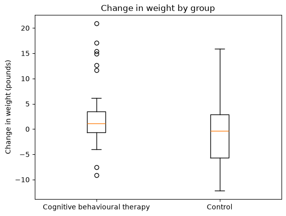

```python
anorexia = pd.read_csv("../data/Anorexia.csv")

cog = anorexia.loc[anorexia['therapy'] == 'cog', 'change']     # treatment group
cont = anorexia.loc[anorexia['therapy'] == 'cont', 'change']   # control group

print(f"Treatment: n = {len(cog)}, mean = {cog.mean():.4f}, median = {cog.median():.4f}, sd = {cog.std():.4f}")
print(f"Control:   n = {len(cont)}, mean = {cont.mean():.4f}, median = {cont.median():.4f}, sd = {cont.std():.4f}")

plt.boxplot([cog, cont], tick_labels=["Cognitive behavioural therapy", "Control"])
plt.ylabel("Change in weight (pounds)")
plt.title("Change in weight by group")
plt.show()
```

The median weight change is slightly higher for the treatment group (1.1 pounds) than for the control group (-0.35 pounds). The treatment group also has several girls with large weight gains (the outliers between about 12 and 21 pounds). However, the two boxes overlap substantially, and the two medians are close to each other.

From the box plots alone, it is not clear that the cognitive behavioural therapy is effective. A formal test is needed.

(b) Let $\mu_1$ and $\mu_2$ denote the population mean weight change for the treatment and control groups respectively. Summarise the assumptions needed to perform a test of $$ H_0: \mu_1 = \mu_2 \quad \text{vs} \quad H_1: \mu_1 \ne \mu_2 $$

```python
print(f"Equal variance test p-value: {stats.levene(cog, cont).pvalue:.4f}")
```

```
Equal variance test p-value: 0.5434
```

**Assumptions**:

- **Randomisation**: The 65 girls were randomly assigned to the two groups.
- **Quantitative variable**: The change in weight is quantitative, and it is the same variable for both groups.
- **Independent samples**: The two groups contain different girls, so the two samples are independent.
- **Normality**: Both sample sizes (33 and 32) are large, so the normality assumption for each group is not required.
- **Equal variances**: The equal variance test has a large $p$-value of 0.5434, so we can assume that the two population variances are equal and use `equal_var=True`.

(c) Carry out the test in part (b). Report and interpret its $p$-value.

```python
results = stats.ttest_ind(cog, cont, equal_var=True, alternative='two-sided')
print(f"t = {results.statistic:.4f}, df = {results.df:.0f}, p-value = {results.pvalue:.4f}")
```

```
t = 1.8121, df = 63, p-value = 0.0747
```

The test statistic is $T = 1.812$, whose null distribution is $t_{63}$ (since $df = 33 + 32 - 2 = 63$), and the $p$-value is 0.0747.

**Interpretation**: If the therapy had no effect on the mean weight change ($\mu_1 = \mu_2$), the probability of observing a difference between the two sample means at least as large as the one observed (2.68 pounds vs -0.48 pounds, a difference of 3.17 pounds), in either direction, is 0.0747.

This $p$-value is not very small. At significance level 0.05, we do not reject $H_0$, so the data do not provide strong evidence that the cognitive behavioural therapy changes the mean weight of girls with anorexia.